Installation of Libraries

```r
library('ggplot2') # visualization
library('car') # visualization
library('scales') # visualization
library('AER') #Coefficients
require("tidyr")
library('corrplot')
#library('caret')
library('purrr')
library('coefplot')
library('psych')
library('MASS')
#library('leaflet.extras')
library("PerformanceAnalytics")
library('GPArotation')
library('MVN')
library('psych')
library('MASS')
library('psy')
library('corpcor')
library('nnet')
library('plyr')
library('car')
library("e1071")
library('ggcorrplot')
library('mlogit')  # for multiple class logistic regression
# library('InformationValue')
library('rpart.plot')
library('caTools')
library('ggplot2')
library('RColorBrewer')
# library('data.table')
# library('ROCR')
# library('maptree')
# library('tree')
library('dummies') # for converting categorical into dummy one
library('caret')
library('pscl') ## for  McFadden R2
library('randomForest')
library('StatMeasures')
library('sqldf')
library('purrr')
library('tidyr')
#library('caret')
library('ggplot2')
library('gains')
library('lubridate')
library('dummies')
library('glmnet')
library('gbm')
library('VIM')  ### This is for knn
library('DMwR')  ## package for SMOTE
library('rpart')
```

Data Loading

```r
setwd("C:/Users/Karthik/Documents/Lakshmi - Back up docs/Learning/Data Analytics/BABI/Sessions/S15/SCLA Assgn")
Data<-read.csv("SCLA_Inventory (1).csv")
```

Basic Data Analysis

```r
nrow(Data)
```

```
## [1] 7853
```

```r
View(Data)
str(Data)
```

```
## 'data.frame':    7853 obs. of  8 variables:
##  $ Order.Date          : Factor w/ 1378 levels "01/01/2008","01/01/2009",..: 446 446 446 446 446 446 446 446 446 450 ...
##  $ Order.ID            : int  24544 24544 24544 20422 55937 20422 17186 55937 17186 11686 ...
##  $ Order.Quantity      : int  31 39 15 30 10 5 11 24 49 38 ...
##  $ Product.Container   : Factor w/ 7 levels "Jumbo Box","Jumbo Drum",..: 4 3 2 6 5 5 5 1 4 5 ...
##  $ Product.Name        : Factor w/ 1257 levels "\"While you Were Out\" Message Book, One Form per Page",..: 316 482 561 814 662 188 1184 295 405 1092 ...
##  $ Product.Sub.Category: Factor w/ 17 levels "Appliances","Binders and Binder Accessories",..: 10 15 4 9 5 8 11 16 9 17 ...
##  $ Sales               : num  6567 1780 578 611 517 ...
##  $ Ship.Mode           : Factor w/ 3 levels "Delivery Truck",..: 2 3 1 3 3 3 3 1 3 3 ...
```

```r
summary(Data)
```

```
##       Order.Date      Order.ID     Order.Quantity   Product.Container
##  9/15/2009 :  20   Min.   :    3   Min.   : 1.00   Jumbo Box : 490
##  3/29/2010 :  19   1st Qu.:14855   1st Qu.:13.00   Jumbo Drum: 573
##  12/12/2008:  18   Median :29637   Median :26.00   Large Box : 378
##  11/19/2009:  17   Mean   :29861   Mean   :25.59   Medium Box: 344
##  2/28/2008 :  17   3rd Qu.:44583   3rd Qu.:38.00   Small Box :4081
##  4/20/2008 :  17   Max.   :59971   Max.   :50.00   Small Pack: 894
##  (Other)   :7745                                   Wrap Bag  :1093
##                                      Product.Name
##  Global High-Back Leather Tilter, Burgundy :  23
##  Bevis 36 x 72 Conference Tables           :  22
##  Master Giant Foot® Doorstop, Safety Yellow:  22
##  80 Minute CD-R Spindle, 100/Pack - Staples:  20
##  Fiskars® Softgrip Scissors                :  20
##  StarTAC 7760                              :  20
##  (Other)                                   :7726
##                      Product.Sub.Category     Sales
##  Paper                         :1153      Min.   :     4
##  Binders and Binder Accessories: 857      1st Qu.:   244
##  Telephones and Communication  : 831      Median :   747
##  Office Furnishings            : 726      Mean   :  3044
##  Computer Peripherals          : 715      3rd Qu.:  2959
##  Pens & Art Supplies           : 589      Max.   :114362
##  (Other)                       :2982
##           Ship.Mode
##  Delivery Truck:1063
##  Express Air   : 921
##  Regular Air   :5869
##
##
##
##
```

Observation: The dataset is about inventory of a firm. The data consists of 7,853 rows with 8 columns. The data spans from 2007 to 2010 timeframe where the business seems to be steadily growing. The objective of the exercise is to find the optimal ship mode for the order placed by the customers.

```r
head(Data, 5)
```

```
##   Order.Date Order.ID Order.Quantity Product.Container
## 1  1/27/2007    24544             31        Medium Box
## 2  1/27/2007    24544             39         Large Box
## 3  1/27/2007    24544             15        Jumbo Drum
## 4  1/27/2007    20422             30        Small Pack
## 5  1/27/2007    55937             10         Small Box
##                             Product.Name   Product.Sub.Category Sales
## 1       Canon MP41DH Printing Calculator        Office Machines  6567
## 2     Fellowes Neat Ideas® Storage Cubes Storage & Organization  1780
## 3 Global Stack Chair without Arms, Black     Chairs & Chairmats   578
## 4             Nu-Dell Leatherette Frames     Office Furnishings   611
## 5    IBM Active Response Keyboard, Black   Computer Peripherals   517
##        Ship.Mode
## 1    Express Air
## 2    Regular Air
## 3 Delivery Truck
## 4    Regular Air
## 5    Regular Air
```

```r
tail(Data, 5)
```

```
##      Order.Date Order.ID Order.Quantity Product.Container
## 7849 12/31/2010    25542             37          Wrap Bag
## 7850 12/31/2010    50950             35         Small Box
## 7851 12/31/2010    45127             10          Wrap Bag
## 7852 12/31/2010    50950              6        Jumbo Drum
## 7853 12/31/2010    47815             45          Wrap Bag
##                                                    Product.Name
## 7849     Black Print Carbonless 8 1/2" x 8 1/4" Rapid Memo Book
## 7850 Tenex Personal Project File with Scoop Front Design, Black
## 7851                                        Binder Clips by OIC
## 7852                                  Novimex Fabric Task Chair
## 7853                                   DAX Wood Document Frame.
##        Product.Sub.Category Sales      Ship.Mode
## 7849                  Paper   706    Express Air
## 7850 Storage & Organization  1266    Express Air
## 7851           Rubber Bands    31    Regular Air
## 7852     Chairs & Chairmats  1105 Delivery Truck
## 7853     Office Furnishings  1571    Regular Air
```

```r
dim(Data)
```

```
## [1] 7853    8
```

```r
colnames(Data)
```

```
## [1] "Order.Date"           "Order.ID"             "Order.Quantity"
## [4] "Product.Container"    "Product.Name"         "Product.Sub.Category"
## [7] "Sales"                "Ship.Mode"
```

Converting data types of the variables Converting the Order.Date to month day year format.

```r
Data$Order.Date <- mdy(Data$Order.Date)
View(Data)
```

Exploratory data analysis & interpretations

```r
levels(as.factor(Data$Ship.Mode))
```

```
## [1] "Delivery Truck" "Express Air"    "Regular Air"
```

```r
Data$Ship.Mode <- factor(Data$Ship.Mode, levels= c("Delivery Truck", "Express Air", "Regular Air"))

mean(Data$Ship.Mode == 'Delivery Truck')
```

```
## [1] 0.1353623
```

```r
mean(Data$Ship.Mode == 'Express Air')
```

```
## [1] 0.11728
```

```r
mean(Data$Ship.Mode == 'Regular Air')
```

```
## [1] 0.7473577
```

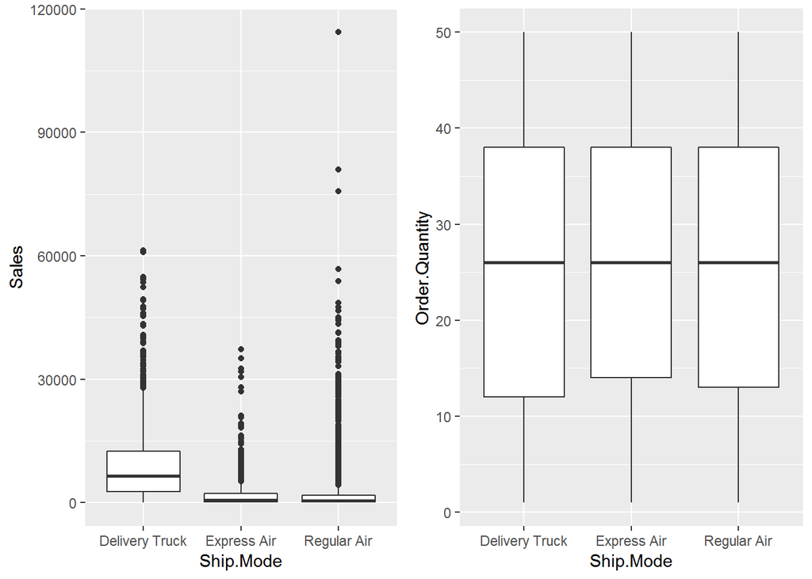

```r
p1 <- ggplot(Data, aes(x= Ship.Mode, y=Sales, fill=Sales)) + geom_boxplot()
p2 <- ggplot(Data, aes(x=Ship.Mode, y=Order.Quantity, fill=Order.Quantity)) + geom_boxplot()

grid.arrange(p1, p2, ncol=2)
```

Observation: The above boxplots Ship.Mode Vs Sales & Order.Quantity shows following observations 1. Sales numbers are higher when using Delivery_Truck as the shipping mode. It may be due to Delivery truck can be used to deliver large quantities of the orders 2. The median order quantity for all the 3 modes of Ship_mode. It suggests that irrespective of any shipping mode the median order quantity remains same.

Orders by Ship_mode

```r
ship_mode <- aggregate(Data$Ship.Mode, by=list(Data$Ship.Mode), FUN=length)
colnames(ship_mode)<-c("ship_mode","Count")
ship_mode[order(-ship_mode$Count),]
```

```
##        ship_mode Count
## 3    Regular Air  5869
## 1 Delivery Truck  1063
## 2    Express Air   921
```

Observation: Regular Air Shipping mode has the highest order followed by Delivery Truck. Express Air Shipping mode has lowest orders. It may be due to higher charges levied on Express modes.

Orders by Product Sub-Category

```r
Product_Sub_Category <- aggregate(Data$Product.Sub.Category, by=list(Data$Product.Sub.Category), FUN=length)
colnames(Product_Sub_Category)<-c("Product_Sub_Category","Count")
head(Product_Sub_Category[order(-Product_Sub_Category$Count),],5)
```

```
##              Product_Sub_Category Count
## 11                          Paper  1153
## 2  Binders and Binder Accessories   857
## 17   Telephones and Communication   831
## 9              Office Furnishings   726
## 5            Computer Peripherals   715
```

Orders by Product Name

```r
Product_Name <- aggregate(Data$Product.Name, by=list(Data$Product.Name), FUN=length)
colnames(Product_Name)<-c("Product_Name","Count")
head(Product_Name[order(-Product_Name$Count),],5)
```

```
##                                   Product_Name Count
## 554  Global High-Back Leather Tilter, Burgundy    23
## 257            Bevis 36 x 72 Conference Tables    22
## 747 Master Giant Foot® Doorstop, Safety Yellow    22
## 63  80 Minute CD-R Spindle, 100/Pack - Staples    20
## 501                 Fiskars® Softgrip Scissors    20
```

Sales by Product Category

```r
sales_prod_cat <-aggregate(Data$Sales, by=list(Category= Data$Product.Sub.Category), FUN=sum)
colnames(sales_prod_cat)<-c("Product_sub_category","Sales")
head(sales_prod_cat[order(-sales_prod_cat$Sales),],5)
```

```
##            Product_sub_category   Sales
## 10              Office Machines 3379000
## 16                       Tables 3113200
## 17 Telephones and Communication 3094814
## 4            Chairs & Chairmats 2769671
## 6               Copiers and Fax 1832471
```

Sales by Ship_mode

```r
sales_ship_mode <-aggregate(Data$Sales, by=list(Category= Data$Ship.Mode), FUN=sum)
colnames(sales_ship_mode)<-c("Ship_mode","Sales")
head(sales_ship_mode[order(-sales_ship_mode$Sales),],5)
```

```
##        Ship_mode    Sales
## 3    Regular Air 12065829
## 1 Delivery Truck  9936921
## 2    Express Air  1898277
```

Total Sales Trend Extract days from order dat

```r
order_dates = Data$Order.Date

head(order_dates)
```

```
## [1] "2007-01-27" "2007-01-27" "2007-01-27" "2007-01-27" "2007-01-27"
## [6] "2007-01-27"
```

```r
order_days <- weekdays(order_dates)

head(order_days)
```

```
## [1] "Saturday" "Saturday" "Saturday" "Saturday" "Saturday" "Saturday"
```

```r
#Extract the year from the data
order_years <- substring(order_dates ,1,4)
head(order_years)
```

```
## [1] "2007" "2007" "2007" "2007" "2007" "2007"
```

```r
sales_days <- data.frame(order_days,Data$Sales,order_dates,order_years)
head(sales_days)
```

```
##   order_days Data.Sales order_dates order_years
## 1   Saturday       6567  2007-01-27        2007
## 2   Saturday       1780  2007-01-27        2007
## 3   Saturday        578  2007-01-27        2007
## 4   Saturday        611  2007-01-27        2007
## 5   Saturday        517  2007-01-27        2007
## 6   Saturday         21  2007-01-27        2007
```

```r
#Edit level order
sales_days$order_days <- factor(sales_days$order_days, levels = c("Monday","Tuesday","Wednesday","Thursday","Friday","Saturday","Sunday"))
```

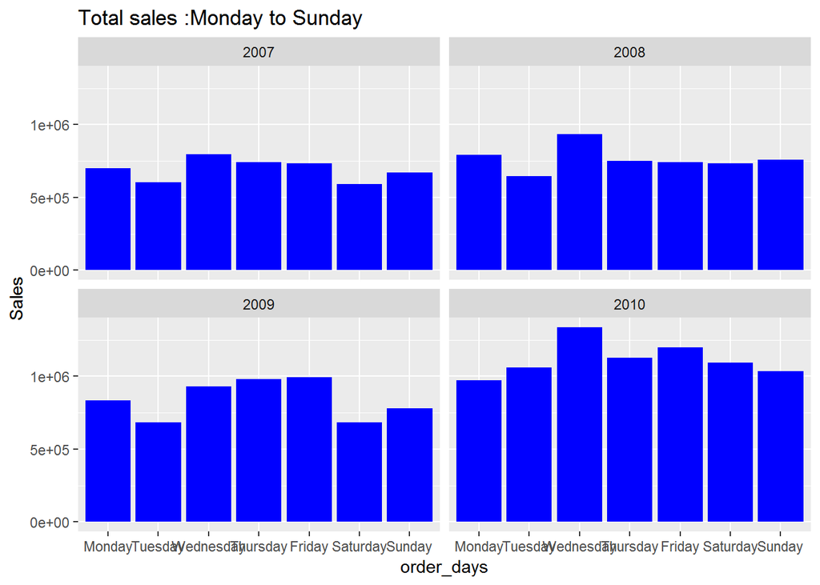

```r
# Sales
ggplot(data=sales_days, aes(x= order_days, y=Data$Sales))+
  geom_bar(stat="identity",show.legend = TRUE,fill="blue")+
  ggtitle("Total sales :Monday to Sunday")+
  facet_wrap(~order_years,ncol=2)+ylab("Sales")
```

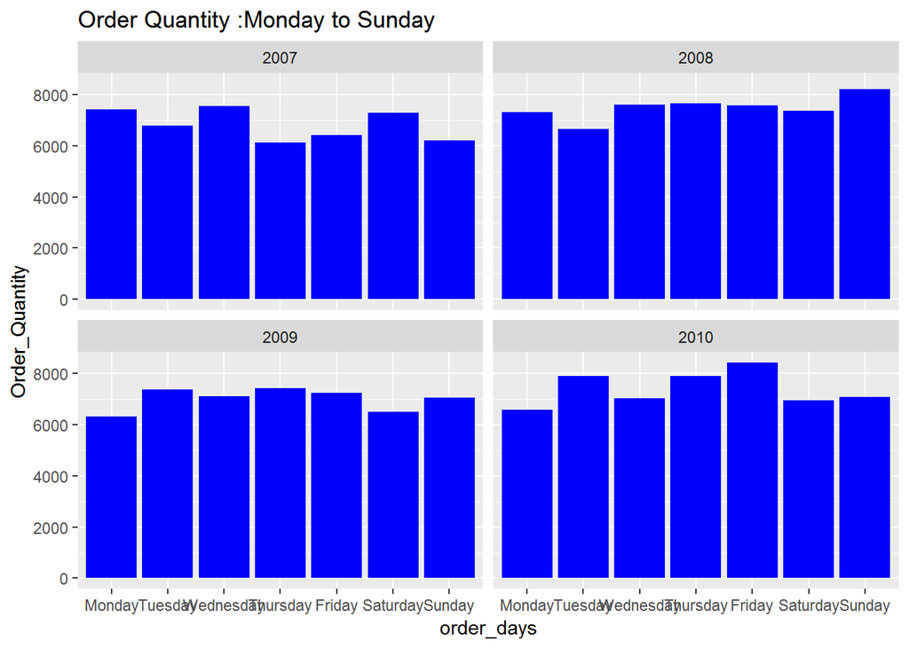

```r
# Order Quantity
ggplot(data=sales_days, aes(x= order_days, y=Data$Order.Quantity))+
  geom_bar(stat="identity",show.legend = TRUE,fill="blue")+
  ggtitle("Order Quantity :Monday to Sunday")+
  facet_wrap(~order_years,ncol=2)+ylab("Order_Quantity")
```

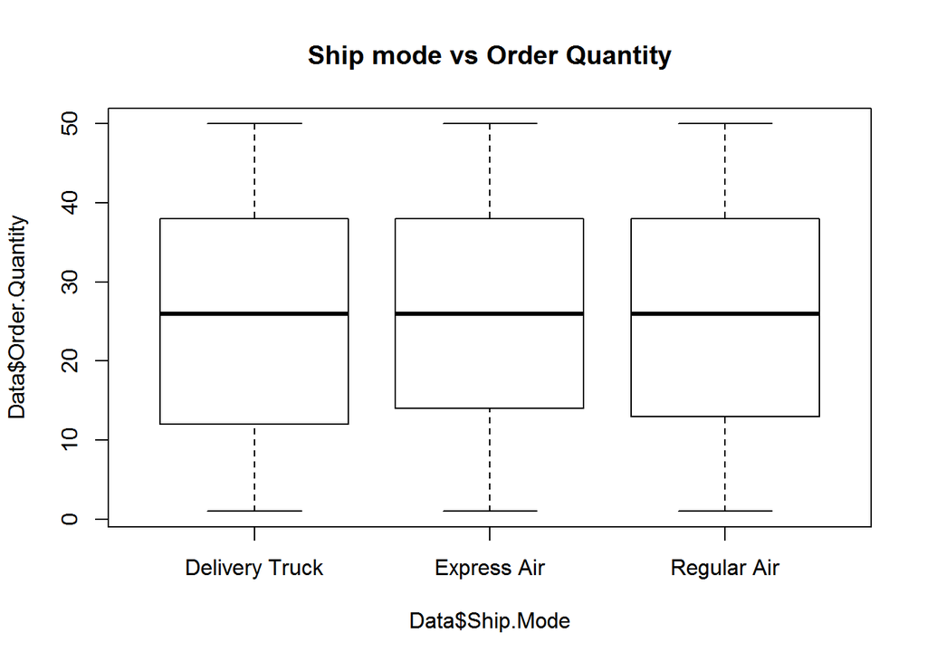

```r
boxplot(Data$Order.Quantity ~Data$Ship.Mode, main = "Ship mode vs Order Quantity")
```

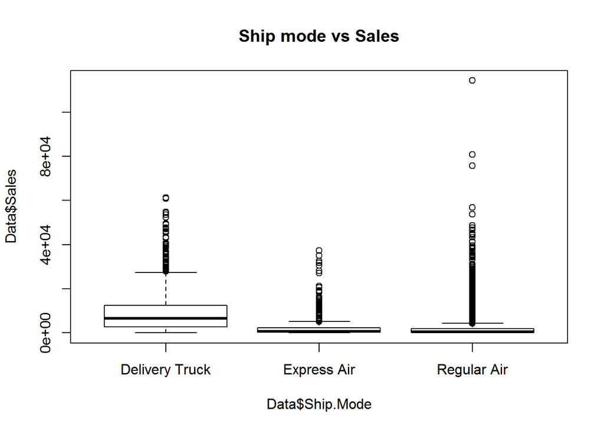

```r
boxplot(Data$Sales ~Data$Ship.Mode, main ="Ship mode vs Sales")
```

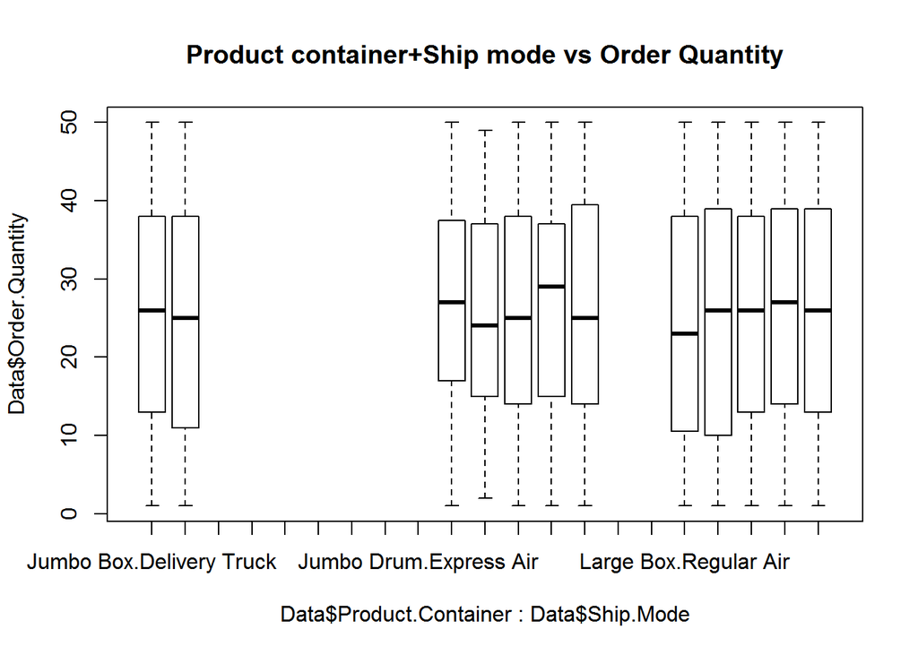

```r
boxplot(Data$Order.Quantity ~Data$Product.Container+Data$Ship.Mode, main = "Product container+Ship mode vs Order Quantity")
```

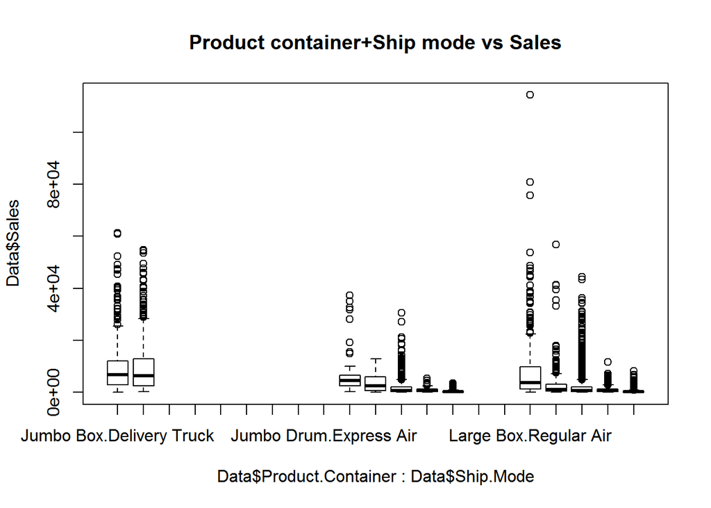

```r
boxplot(Data$Sales ~Data$Product.Container+Data$Ship.Mode, main ="Product container+Ship mode vs Sales")
```

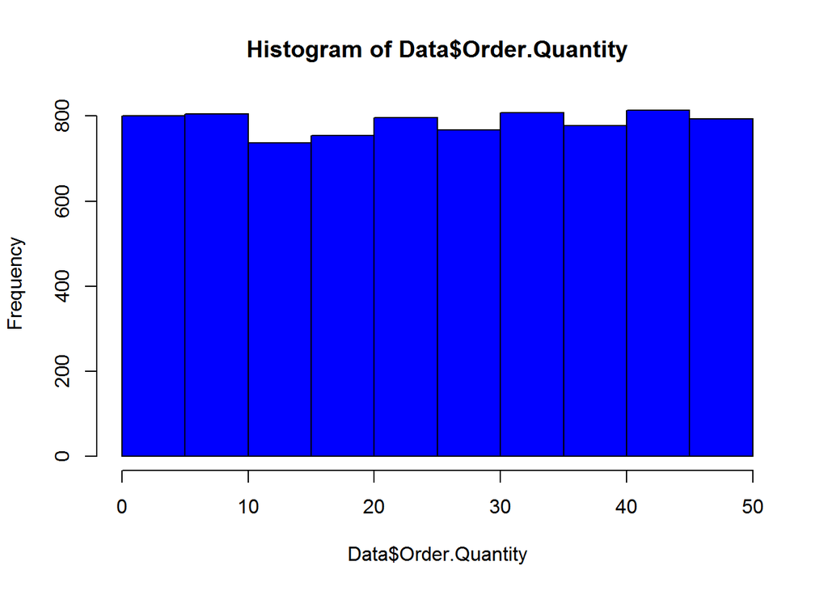

```r
hist(Data$Order.Quantity, col = 'blue')
```

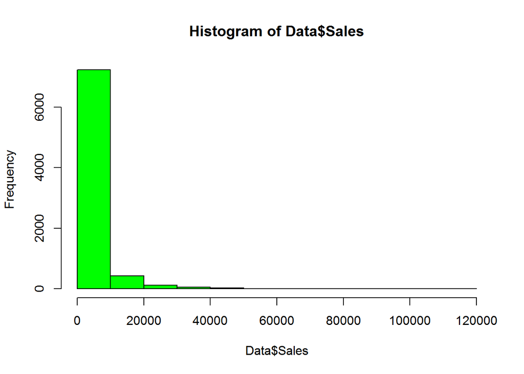

```r
hist(Data$Sales, col = 'green')
```

```r
#outlier function
outlierKD <- function(dt, var) {
  var_name <- eval(substitute(var),eval(dt))
  na1 <- sum(is.na(var_name))
  m1 <- mean(var_name, na.rm = T)
  par(mfrow=c(2, 2), oma=c(0,0,3,0))
  boxplot(var_name, main="With outliers")
  hist(var_name, main="With outliers", xlab=NA, ylab=NA)
  outlier <- boxplot.stats(var_name)$out
  mo <- mean(outlier)
  var_name <- ifelse(var_name %in% outlier, NA, var_name)
  boxplot(var_name, main="Without outliers")
  hist(var_name, main="Without outliers", xlab=NA, ylab=NA)
  title("Outlier Check", outer=TRUE)
  na2 <- sum(is.na(var_name))
  cat("Outliers identified:", na2 - na1, "n")
  cat("Propotion (%) of outliers:", round((na2 - na1) / sum(!is.na(var_name))*100, 1), "n")
  cat("Mean of the outliers:", round(mo, 2), "n")
  m2 <- mean(var_name, na.rm = T)
  cat("Mean without removing outliers:", round(m1, 2), "n")
  cat("Mean if we remove outliers:", round(m2, 2), "n")
  response <- readline(prompt="Do you want to remove outliers and to replace with NA? [yes/no]: ")
  if(response == "y" | response == "yes"){
    dt[as.character(substitute(var))] <- invisible(var_name)
    assign(as.character(as.list(match.call())$dt), dt, envir = .GlobalEnv)
    cat("Outliers successfully removed", "n")
    return(invisible(dt))
  } else{
    cat("Nothing changed", "n")
    return(invisible(var_name))
  }
}
```

Build a function to calculate percentage of missing values in Columns and Rows

```r
pMiss = function(x){
  sum(is.na(x))/length(x)*100
}
```

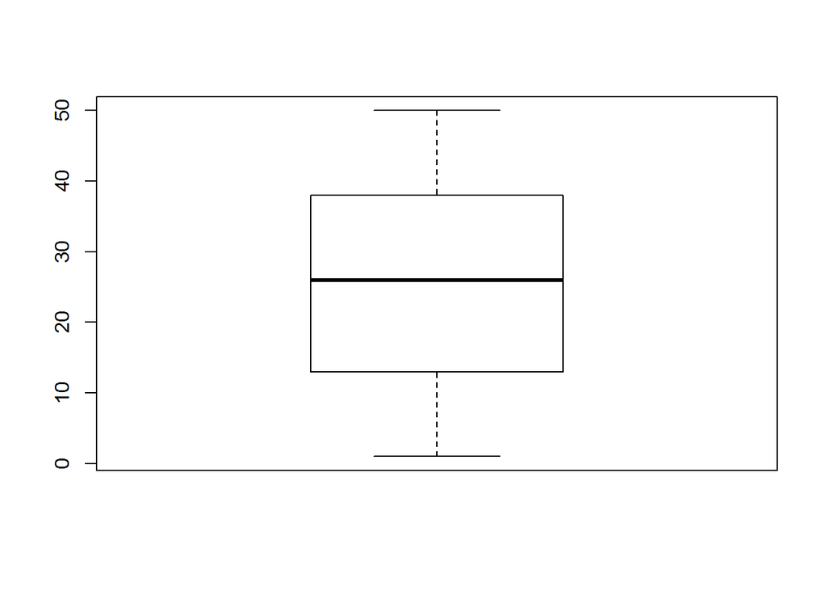

```
##       Length Class   Mode
## stats 5      integer numeric
## n     1      -none-  numeric
## conf  2      -none-  numeric
## out   0      -none-  numeric
## group 0      -none-  numeric
## names 1      -none-  character
```

```r
par(mfrow=c(1, 1))
boxplot(Data$Order.Quantity)
summary(boxplot(Data$Order.Quantity))
```

```r
boxplot.stats(Data$Order.Quantity)$out
```

```
## integer(0)
```

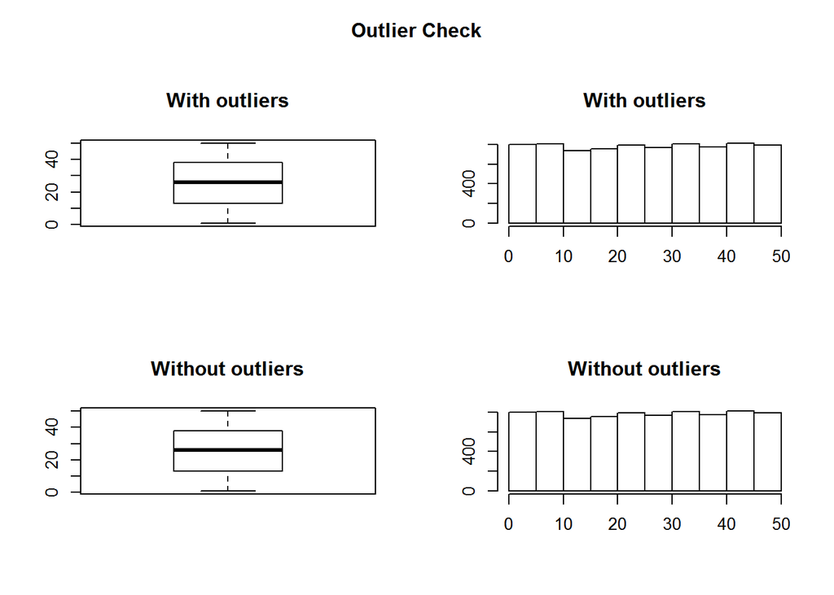

```
## Outliers identified: 0 nPropotion (%) of outliers: 0 nMean of the outliers: NaN nMean without removing outliers: 25.59 nMean if we remove outliers: 25.59 nDo you want to remove outliers and to replace with NA? [yes/no]:
## Nothing changed n
```

```r
outlierKD(Data, Order.Quantity)
```

```r
aggregate(Data$Order.Quantity,by=list(Category=Data$Product.Container), FUN=sum)
```

```
##     Category      x
## 1  Jumbo Box  12606
## 2 Jumbo Drum  14240
## 3  Large Box   9206
## 4 Medium Box   8689
## 5  Small Box 104488
## 6 Small Pack  23564
## 7   Wrap Bag  28174
```

```r
aggregate(Data$Order.Quantity,by=list(Category=Data$Product.Sub.Category), FUN=sum)
```

```
##                          Category     x
## 1                      Appliances 10047
## 2  Binders and Binder Accessories 21356
## 3                       Bookcases  4443
## 4              Chairs & Chairmats  8780
## 5            Computer Peripherals 18111
## 6                 Copiers and Fax  2069
## 7                       Envelopes  6155
## 8                          Labels  6924
## 9              Office Furnishings 19153
## 10                Office Machines  7396
## 11                          Paper 29108
## 12            Pens & Art Supplies 15727
## 13                   Rubber Bands  4609
## 14  Scissors, Rulers and Trimmers  3591
## 15         Storage & Organization 13090
## 16                         Tables  8604
## 17   Telephones and Communication 21804
```

```r
aggregate(Data$Order.Quantity,by=list(Category=Data$Ship.Mode), FUN=sum)
```

```
##         Category      x
## 1 Delivery Truck  26846
## 2    Express Air  23696
## 3    Regular Air 150425
```

```r
aggregate(Data$Order.Quantity,by=list(Category=Data$Product.Container), FUN=mean)
```

```
##     Category        x
## 1  Jumbo Box 25.72653
## 2 Jumbo Drum 24.85166
## 3  Large Box 24.35450
## 4 Medium Box 25.25872
## 5  Small Box 25.60353
## 6 Small Pack 26.35794
## 7   Wrap Bag 25.77676
```

```r
aggregate(Data$Order.Quantity,by=list(Category=Data$Product.Sub.Category), FUN=mean)
```

```
##                          Category        x
## 1                      Appliances 25.18045
## 2  Binders and Binder Accessories 24.91949
## 3                       Bookcases 25.83140
## 4              Chairs & Chairmats 24.94318
## 5            Computer Peripherals 25.33007
## 6                 Copiers and Fax 25.23171
## 7                       Envelopes 26.87773
## 8                          Labels 25.45588
## 9              Office Furnishings 26.38154
## 10                Office Machines 23.33123
## 11                          Paper 25.24545
## 12            Pens & Art Supplies 26.70119
## 13                   Rubber Bands 27.27219
## 14  Scissors, Rulers and Trimmers 27.20455
## 15         Storage & Organization 25.12476
## 16                         Tables 25.53116
## 17   Telephones and Communication 26.23827
```

```r
aggregate(Data$Order.Quantity,by=list(Category=Data$Ship.Mode), FUN=mean)
```

```
##         Category        x
## 1 Delivery Truck 25.25494
## 2    Express Air 25.72856
## 3    Regular Air 25.63043
```

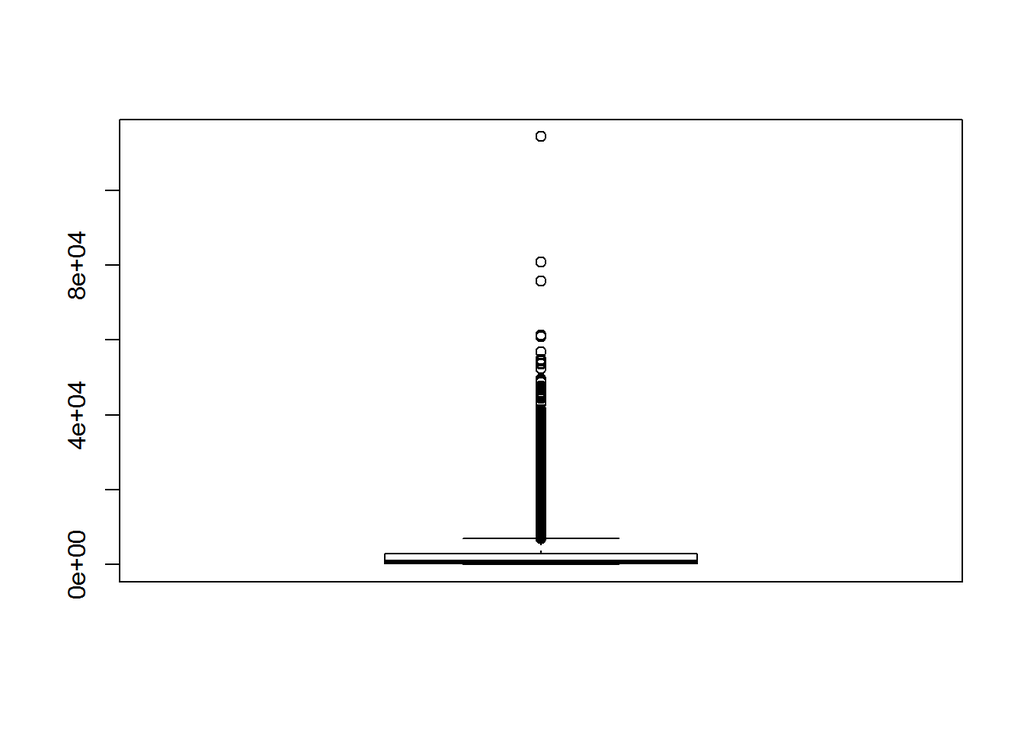

```
##       Length Class  Mode
## stats   5    -none- numeric
## n       1    -none- numeric
## conf    2    -none- numeric
## out   951    -none- numeric
## group 951    -none- numeric
## names   1    -none- character
```

```r
boxplot(Data$Sales)
summary(boxplot(Data$Sales))
```

```r
aggregate(Data$Sales,by=list(Category=Data$Product.Container), FUN=sum)
```

```
##     Category       x
## 1  Jumbo Box 4554165
## 2 Jumbo Drum 5382756
## 3  Large Box 3197166
## 4 Medium Box 1165242
## 5  Small Box 8246744
## 6 Small Pack  894136
## 7   Wrap Bag  460818
```

```r
aggregate(Data$Sales,by=list(Category=Data$Product.Sub.Category), FUN=sum)
```

```
##                          Category       x
## 1                      Appliances 1186803
## 2  Binders and Binder Accessories 1666093
## 3                       Bookcases 1222861
## 4              Chairs & Chairmats 2769671
## 5            Computer Peripherals 1298630
## 6                 Copiers and Fax 1832471
## 7                       Envelopes  293189
## 8                          Labels   62966
## 9              Office Furnishings 1077893
## 10                Office Machines 3379000
## 11                          Paper  723495
## 12            Pens & Art Supplies  264353
## 13                   Rubber Bands   25512
## 14  Scissors, Rulers and Trimmers  158555
## 15         Storage & Organization 1731521
## 16                         Tables 3113200
## 17   Telephones and Communication 3094814
```

```r
aggregate(Data$Sales,by=list(Category=Data$Ship.Mode), FUN=sum)
```

```
##         Category        x
## 1 Delivery Truck  9936921
## 2    Express Air  1898277
## 3    Regular Air 12065829
```

```r
aggregate(Data$Sales,by=list(Category=Data$Product.Container), FUN=mean)
```

```
##     Category         x
## 1  Jumbo Box 9294.2143
## 2 Jumbo Drum 9393.9895
## 3  Large Box 8458.1111
## 4 Medium Box 3387.3314
## 5  Small Box 2020.7655
## 6 Small Pack 1000.1521
## 7   Wrap Bag  421.6084
```

```r
aggregate(Data$Sales,by=list(Category=Data$Product.Sub.Category), FUN=mean)
```

```
##                          Category          x
## 1                      Appliances  2974.4436
## 2  Binders and Binder Accessories  1944.0992
## 3                       Bookcases  7109.6570
## 4              Chairs & Chairmats  7868.3835
## 5            Computer Peripherals  1816.2657
## 6                 Copiers and Fax 22347.2073
## 7                       Envelopes  1280.3013
## 8                          Labels   231.4926
## 9              Office Furnishings  1484.7011
## 10                Office Machines 10659.3060
## 11                          Paper   627.4892
## 12            Pens & Art Supplies   448.8166
## 13                   Rubber Bands   150.9586
## 14  Scissors, Rulers and Trimmers  1201.1742
## 15         Storage & Organization  3323.4568
## 16                         Tables  9237.9822
## 17   Telephones and Communication  3724.2046
```

```r
aggregate(Data$Sales,by=list(Category=Data$Ship.Mode), FUN=mean)
```

```
##         Category        x
## 1 Delivery Truck 9347.997
## 2    Express Air 2061.104
## 3    Regular Air 2055.858
```

```r
boxplot.stats(Data$Sales)$out
```

```
##   [1]   9652   8562  22457  22817   7373   9572   7625  21770   8482   8586
##  [11]  10785  12101  18764  10728   7662  12409   8322  19639  13547  12088
##  [21]  14748  23579  18644  12522  13672   8214  10983  17361  23006   9996
##  [31]   9888  13845  12027   8521  21424 114362   8780   8221  15311  12137
##  [41]  20491   7191  13003   8380  18940  10376  15610  11291   8307  19403
##  [51]  18869  24095  24994  11674   9125  10811  10501   9225  11788  15268
##  [61]   8789   9363  13622   8133  10382  12037   7831   7785  10884   7058
##  [71]  18464  12778  11612  29180  11376  11910  12044  18170  10812  11462
##  [81]   9424  22410  15545   8248  10284   9269  23120  28045   8101   7646
##  [91]   8044   7472   7273  11284  32434   9688   9191  18851   7206  40220
## [101]  16077   8130  26128   7640  16330  11355   8071  18322  26650   8400
## [111]  13202  35595  10345   8249  11281  23554  17784  16529   8132  17599
## [121]  10754  12862  11752  11265  11053  28189  16462   9339   8998  10648
## [131]   7507   8763  34363   8841  14269   9597  12055  10431  36264  10160
## [141]   8117   7876   7230   8462  30741  12630  10011  36710  18081  22793
```

[output cut: 81 more lines]

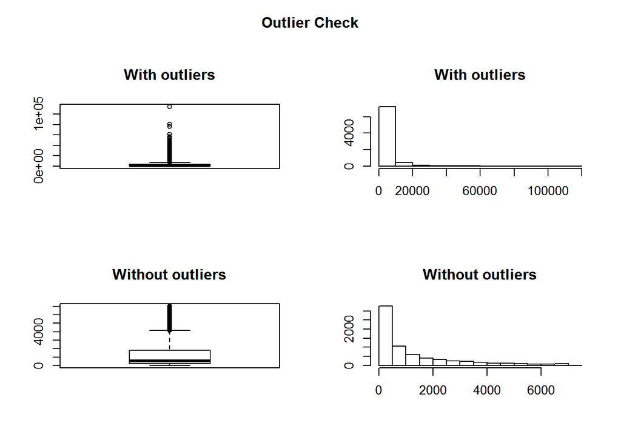

```
## Outliers identified: 951 nPropotion (%) of outliers: 13.8 nMean of the outliers: 15795.87 nMean without removing outliers: 3043.55 nMean if we remove outliers: 1286.46 nDo you want to remove outliers and to replace with NA? [yes/no]:
## Nothing changed n
```

```r
outlierKD(Data, Sales)
```

Correlation plot

```r
my_num_data <- Data[, sapply(Data, is.numeric)]
cor.Data<-cor(my_num_data)
round(cor.Data,2)
```

```
##                Order.ID Order.Quantity Sales
## Order.ID           1.00           0.01  0.00
## Order.Quantity     0.01           1.00  0.22
## Sales              0.00           0.22  1.00
```

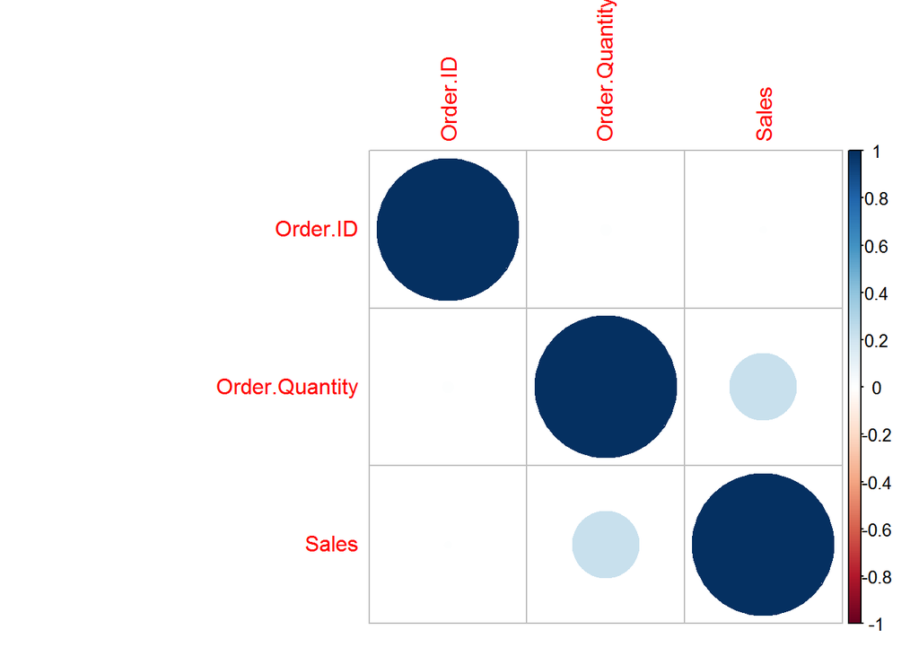

```r
library(corrplot)
corrplot(cor.Data,method="circle",bg="white")
```

Find Percentage of missing values in each column

```r
col_miss = apply(Data,2,pMiss)  ## 2 is for Columns
col_miss
```

```
##           Order.Date             Order.ID       Order.Quantity
##                    0                    0                    0
##    Product.Container         Product.Name Product.Sub.Category
##                    0                    0                    0
##                Sales            Ship.Mode
##                    0                    0
```

Understanding of data balancing nature

```r
table(Data$Ship.Mode)
```

```
##
## Delivery Truck    Express Air    Regular Air
##           1063            921           5869
```

```r
print(prop.table(table(Data$Ship.Mode)))
```

```
##
## Delivery Truck    Express Air    Regular Air
##      0.1353623      0.1172800      0.7473577
```

```r
attach(Data)
names(Data)
```

```
## [1] "Order.Date"           "Order.ID"             "Order.Quantity"
## [4] "Product.Container"    "Product.Name"         "Product.Sub.Category"
## [7] "Sales"                "Ship.Mode"
```

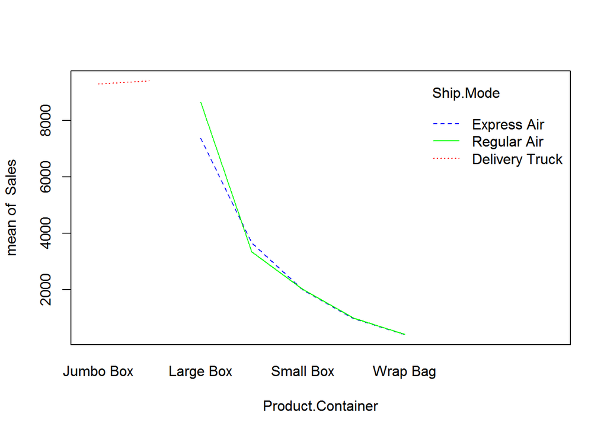

```r
par(mfrow=c(1, 1))

interaction.plot(Product.Container,Ship.Mode,Sales,
                 col = c("Red","Blue","Green"))
```

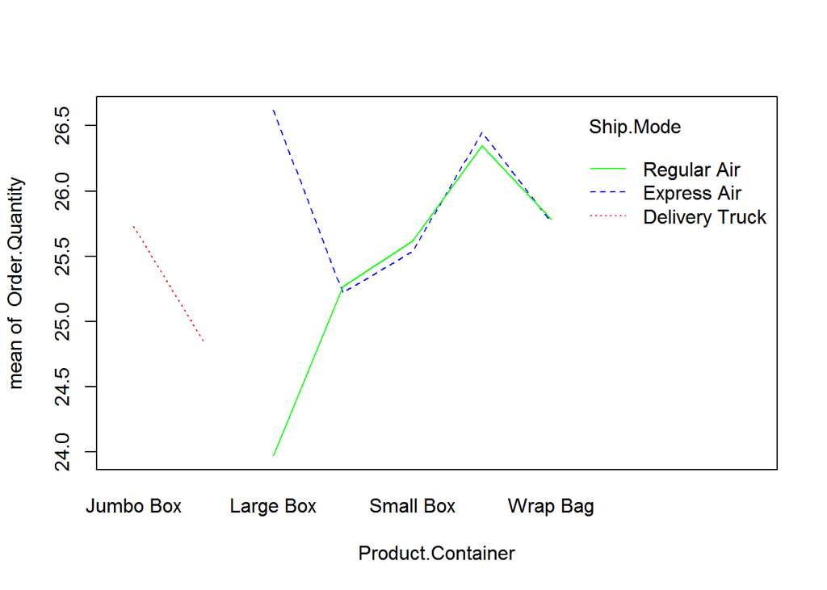

```r
interaction.plot(Product.Container,Ship.Mode,Order.Quantity,
                 col = c("Red","Blue","Green"))
```

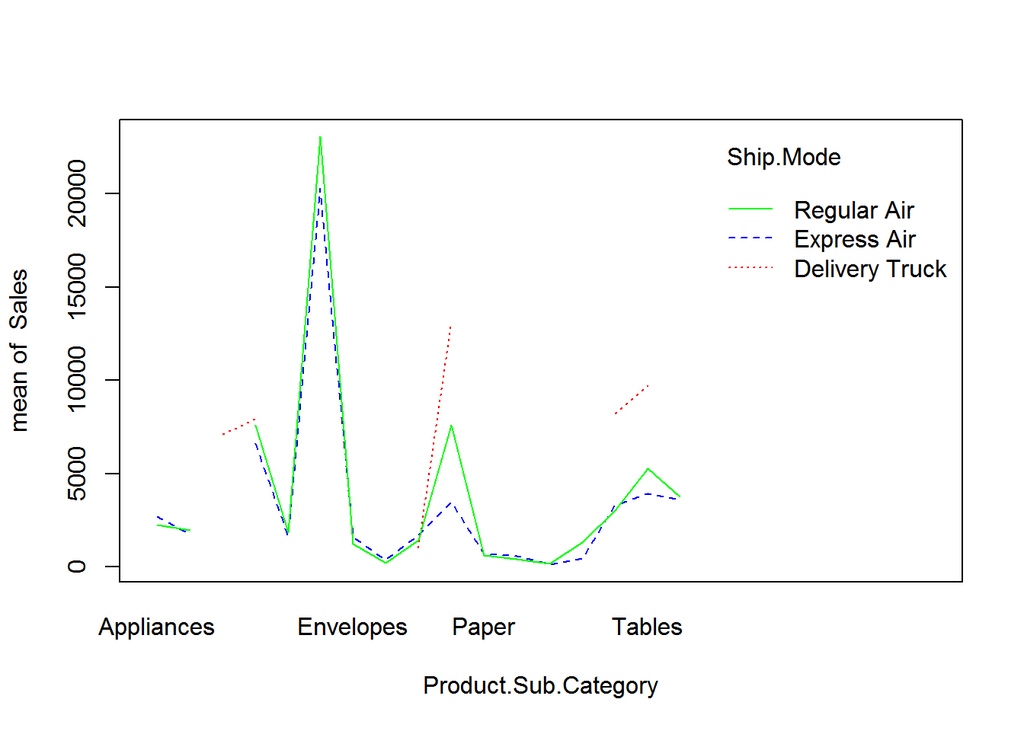

```r
interaction.plot(Product.Sub.Category,Ship.Mode,Sales,
                 col = c("Red","Blue","Green"))
```

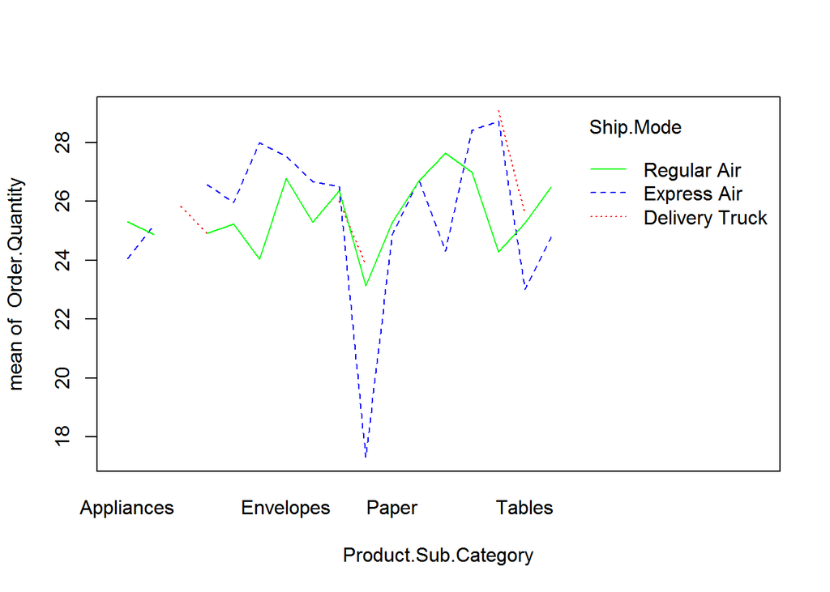

```r
interaction.plot(Product.Sub.Category,Ship.Mode,Order.Quantity,
                 col = c("Red","Blue","Green"))
```

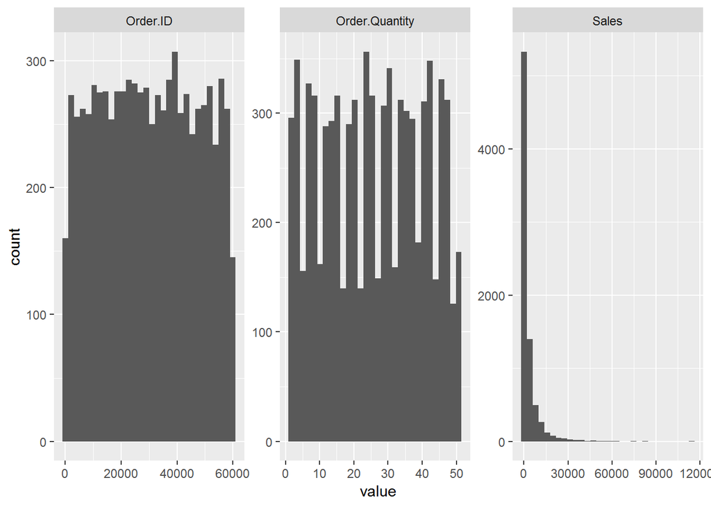

```r
Data %>%
  keep(is.numeric) %>%
  gather() %>%
  ggplot(aes(value)) +
  facet_wrap(~ key, scales = "free") +
  geom_histogram()
```

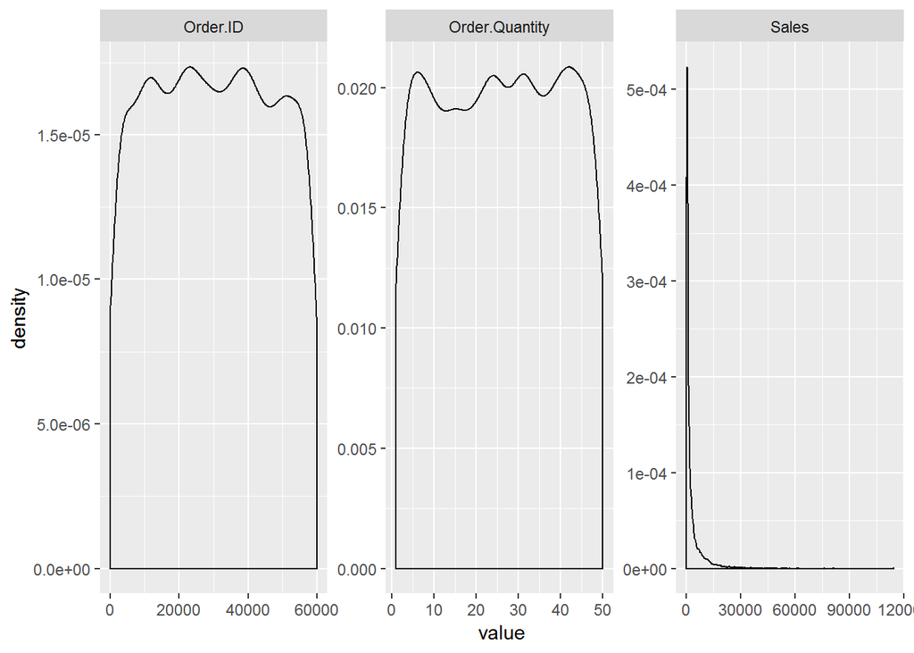

```r
## density diagram for all the variables
Data %>%
  keep(is.numeric) %>%                     # Keep only numeric columns
  gather() %>%                             # Convert to key-value pairs
  ggplot(aes(value)) +                     # Plot the values
  facet_wrap(~ key, scales = "free") +   # In separate panels
  geom_density()
```

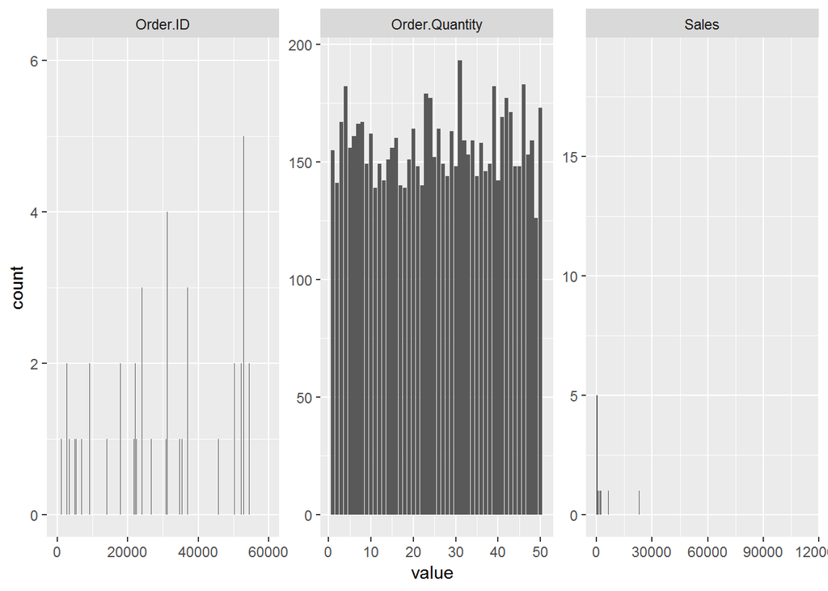

```r
## density diagram for all the variables
Data %>%
  keep(is.numeric) %>%                     # Keep only numeric columns
  gather() %>%                             # Convert to key-value pairs
  ggplot(aes(value)) +                     # Plot the values
  facet_wrap(~ key, scales = "free") +   # In separate panels
  geom_bar()
```

```r
table(Ship.Mode)
```

```
## Ship.Mode
## Delivery Truck    Express Air    Regular Air
##           1063            921           5869
```

```r
prop.table(table(Ship.Mode))
```

```
## Ship.Mode
## Delivery Truck    Express Air    Regular Air
##      0.1353623      0.1172800      0.7473577
```

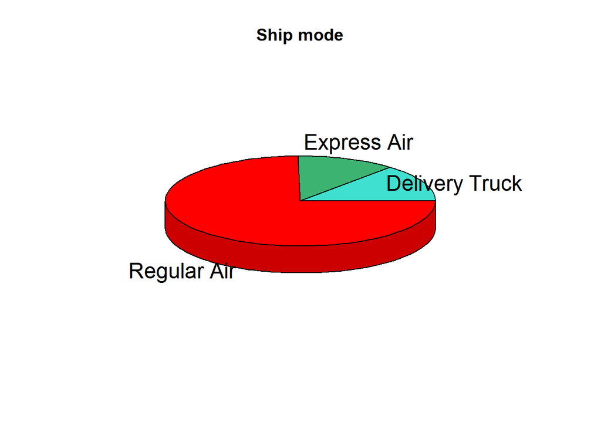

```r
library(plotrix)
pie3D(prop.table(table(Ship.Mode)),
      main='Ship mode',
      #explode=0.05,
      labels=c("Delivery Truck","Express Air", "Regular Air"),
      col = c("Turquoise", "Medium Sea Green","Red")
)
```

```r
table(Product.Container)
```

```
## Product.Container
##  Jumbo Box Jumbo Drum  Large Box Medium Box  Small Box Small Pack
##        490        573        378        344       4081        894
##   Wrap Bag
##       1093
```

```r
prop.table(table(Product.Container))
```

```
## Product.Container
##  Jumbo Box Jumbo Drum  Large Box Medium Box  Small Box Small Pack
## 0.06239654 0.07296575 0.04813447 0.04380492 0.51967401 0.11384184
##   Wrap Bag
## 0.13918248
```

```r
pie3D(prop.table(table(Product.Container)),
      main='Product Container',
      #explode=0.05,
      labels=c("Jumbo Box", "Jumbo Drum","Large Box","Medium Box","Small Box","Small Pack","Wrap Bag"),
      col = c("Red", "Blue","Green","Yellow","Orange","Brown","Turquoise")
)
```

[figure not shown]

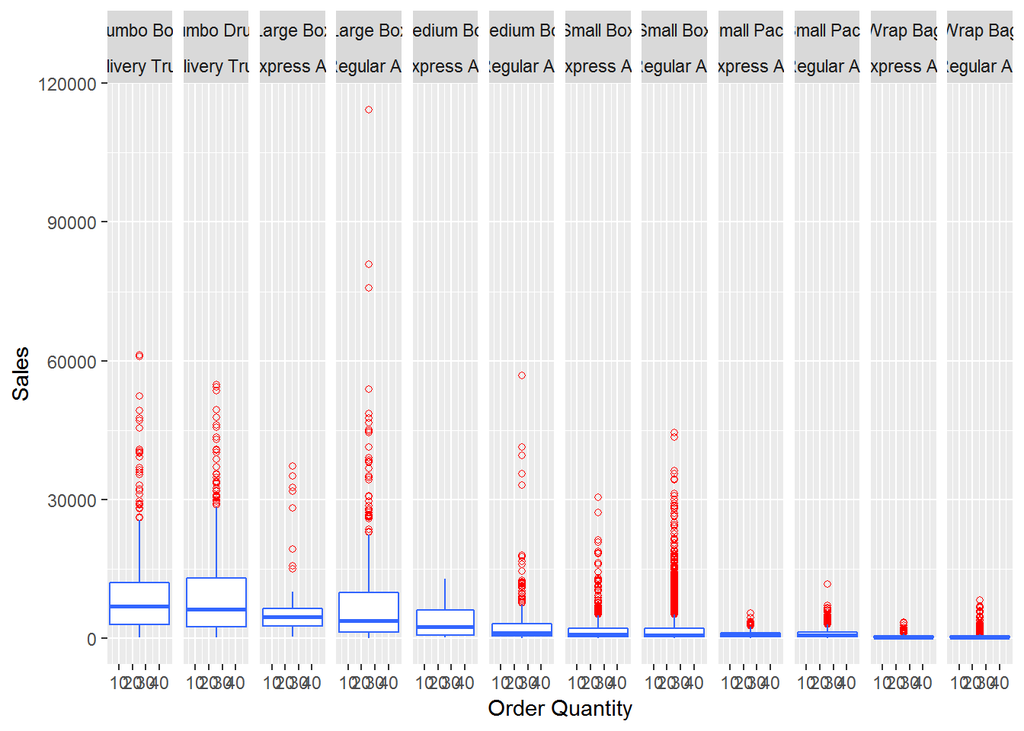

```r
vis_summary <- ggplot(Data, aes(x = Data$Order.Quantity, y = Data$Sales)) +
  facet_grid(~ Data$Product.Container + Data$Ship.Mode)+
  geom_boxplot(na.rm = TRUE, colour = "#3366FF",outlier.colour = "red", outlier.shape = 1) +
  labs(x = "Order Quantity", y = "Sales") +
  scale_x_continuous() +
  scale_y_continuous() +
  theme(legend.position="bottom", legend.direction="horizontal")
vis_summary
```

Model Building

```r
#install.packages("caret",dependencies = TRUE)
library(caret)

inventory_df <- Data

colnames(inventory_df)
```

```
## [1] "Order.Date"           "Order.ID"             "Order.Quantity"
## [4] "Product.Container"    "Product.Name"         "Product.Sub.Category"
## [7] "Sales"                "Ship.Mode"
```

```r
inventory_df$Order.Date <- NULL
inventory_df$Order.ID <- NULL
inventory_df$Product.Name <- NULL

# Data partition
intrain <- createDataPartition(y = inventory_df$Ship.Mode, p = 0.70, list = FALSE)
train_df <- inventory_df[intrain,]
test_df <- inventory_df[-intrain,]

dim(train_df)
```

```
## [1] 5499    5
```

```r
dim(test_df)
```

```
## [1] 2354    5
```

##### Multi-Nominal Logistic Regression

```r
mlr.fit  <- multinom(train_df$Ship.Mode ~ ., train_df, maxit =1000)
summary(mlr.fit)
```

```
## Call:
## multinom(formula = train_df$Ship.Mode ~ ., data = train_df, maxit = 1000)
##
## Coefficients:
##             (Intercept) Order.Quantity Product.ContainerJumbo Drum
## Express Air   -39.73766     0.07135092                   -23.65985
## Regular Air   -61.34967     0.06986554                    21.02729
##             Product.ContainerLarge Box Product.ContainerMedium Box
## Express Air                   78.59834                    67.83261
## Regular Air                  101.60556                    90.89863
##             Product.ContainerSmall Box Product.ContainerSmall Pack
## Express Air                   68.72604                    63.76478
## Regular Air                   91.91312                    86.99057
##             Product.ContainerWrap Bag
## Express Air                  74.10634
## Regular Air                  97.30087
##             Product.Sub.CategoryBinders and Binder Accessories
## Express Air                                          -6.416128
## Regular Air                                          -6.059295
##             Product.Sub.CategoryBookcases
## Express Air                      9.894744
## Regular Air                      9.474421
##             Product.Sub.CategoryChairs & Chairmats
## Express Air                              0.1957928
## Regular Air                              0.7295735
##             Product.Sub.CategoryComputer Peripherals
## Express Air                                -10.57317
## Regular Air                                -10.28542
##             Product.Sub.CategoryCopiers and Fax
## Express Air                            15.66876
## Regular Air                            15.90321
##             Product.Sub.CategoryEnvelopes Product.Sub.CategoryLabels
## Express Air                     -7.610135                  -10.49831
## Regular Air                     -7.099017                   -9.98690
##             Product.Sub.CategoryOffice Furnishings
## Express Air                               1.989950
## Regular Air                               2.349258
##             Product.Sub.CategoryOffice Machines Product.Sub.CategoryPaper
## Express Air                            7.070651                 -11.16436
## Regular Air                            8.651108                 -10.84597
```

[output cut: 62 more lines]

```
##             Product.Sub.CategoryScissors, Rulers and Trimmers
## Express Air                                      0.0006093117
## Regular Air                                      0.0006093117
##             Product.Sub.CategoryStorage & Organization
## Express Air                                0.001920664
## Regular Air                                0.001920664
##             Product.Sub.CategoryTables
## Express Air               0.0001242376
## Regular Air               0.0001242376
##             Product.Sub.CategoryTelephones and Communication      Sales
## Express Air                                       0.00303965 0.02756579
## Regular Air                                       0.00303965 0.02756579
##
## Residual Deviance: 3757.512
## AIC: 3857.512
```

```r
# Prediction on Train_data
mlr_train_pred <- predict(mlr.fit, train_df, type = "class")

# Accuracy and other metrics on train_data
confusionMatrix(mlr_train_pred, train_df$Ship.Mode)
```

```
## Confusion Matrix and Statistics
##
##                 Reference
## Prediction       Delivery Truck Express Air Regular Air
##   Delivery Truck            745           0           0
##   Express Air                 0           0           0
##   Regular Air                 0         645        4109
##
## Overall Statistics
##
##                Accuracy : 0.8827
##                  95% CI : (0.8739, 0.8911)
##     No Information Rate : 0.7472
##     P-Value [Acc > NIR] : < 2.2e-16
##
##                   Kappa : 0.6505
##
##  Mcnemar's Test P-Value : NA
##
## Statistics by Class:
##
##                      Class: Delivery Truck Class: Express Air
## Sensitivity                         1.0000             0.0000
## Specificity                         1.0000             1.0000
## Pos Pred Value                      1.0000                NaN
## Neg Pred Value                      1.0000             0.8827
## Prevalence                          0.1355             0.1173
## Detection Rate                      0.1355             0.0000
## Detection Prevalence                0.1355             0.0000
## Balanced Accuracy                   1.0000             0.5000
##                      Class: Regular Air
## Sensitivity                      1.0000
## Specificity                      0.5360
## Pos Pred Value                   0.8643
## Neg Pred Value                   1.0000
## Prevalence                       0.7472
## Detection Rate                   0.7472
## Detection Prevalence             0.8645
## Balanced Accuracy                0.7680
```

```r
# Predictions on test data
mlr_test_pred <- predict(mlr.fit, test_df, type = "class")

# Accuracy and other metrics on test data
confusionMatrix(mlr_test_pred, test_df$Ship.Mode)
```

```
## Confusion Matrix and Statistics
##
##                 Reference
## Prediction       Delivery Truck Express Air Regular Air
##   Delivery Truck            318           0           0
##   Express Air                 0           0           0
##   Regular Air                 0         276        1760
##
## Overall Statistics
##
##                Accuracy : 0.8828
##                  95% CI : (0.8691, 0.8955)
##     No Information Rate : 0.7477
##     P-Value [Acc > NIR] : < 2.2e-16
##
##                   Kappa : 0.6501
##
##  Mcnemar's Test P-Value : NA
##
## Statistics by Class:
##
##                      Class: Delivery Truck Class: Express Air
## Sensitivity                         1.0000             0.0000
## Specificity                         1.0000             1.0000
## Pos Pred Value                      1.0000                NaN
## Neg Pred Value                      1.0000             0.8828
## Prevalence                          0.1351             0.1172
## Detection Rate                      0.1351             0.0000
## Detection Prevalence                0.1351             0.0000
## Balanced Accuracy                   1.0000             0.5000
##                      Class: Regular Air
## Sensitivity                      1.0000
## Specificity                      0.5354
## Pos Pred Value                   0.8644
## Neg Pred Value                   1.0000
## Prevalence                       0.7477
## Detection Rate                   0.7477
## Detection Prevalence             0.8649
## Balanced Accuracy                0.7677
```